# Indexed Variant Subsets on OGS-00009 — HapMap3 full-statistic extraction

A reproducible single-run benchmark · sub-second full-result LDSC extraction with exact six-field equivalence

Published

October 11, 2026

**ImportantResult**

On OGS-00009, with a **full-statistic** index (Z, SE and EAF — not a Z-only projection), the indexed full result for `ukb-b-17805` returns in **456.6 ms warm median** (1,178,549 associations), against **17.20 s** for the ordinary primary-plane path — a **38x** improvement.

The ordinary read is measured **before** the subset is built and again **after** it, in the same run against a scratch copy of the authoritative release; the artifact records `ordinary_bracketed = True`. Exact decoded equivalence across all six result fields is **True**; publication status: **published**.

## Scope

| Property | Value |
| --- | --- |
| Store Release | OGS-00009 (`OGS-00009`) |
| Primary layout | dense |
| Completion state | observed_only |
| Analyses | 2,024 |
| Variants (Store axis) | 9,847,701 |
| Store format version | 0.1.0 |
| Store Encoding | eaf `int8_residual`, se `int8_residual`, z `int16_fixed` (v3) |
| Reference Assembly | GRCh38 |
| Selected Analysis | `ukb-b-17805` |
| Indexed Variant Subset | `hm3` |
| Run mode | fresh |
| Measured at (UTC) | 2026-10-10T23:30:47.773289+00:00 |
| Git commit | `a36ea78` |
| opengwasdb fingerprint | `3e15ebba785a8538…` |

The package version and the Store Release `format_version` are different things and move independently.

| Store path | Value | Role |
| --- | --- | --- |
| Authoritative source | `/data/opengwasdb/stores/OGS-00009/store.opengwasdb` | never written |
| Measured scratch copy | `/data/opengwasdb/work/270-indexed/store-copy.opengwasdb` | `copy_kind = reflink` |
| Copy method recorded | verified (`reflink`/`full_copy`) or `reused_scratch_copy` |  |

The build writes only inside the scratch copy. The original release’s recursive metadata fingerprint and its `manifest.json`/`analyses.tsv` hashes are compared before and after the run.

| Run bracket | State |
| --- | --- |
| subset present during ordinary_before | False |
| subset published by this run | True |
| ordinary before/after bracketed | True |
| run started (UTC) | 2026-10-10T23:22:41.526729+00:00 |
| run finished (UTC) | 2026-10-10T23:30:43.300215+00:00 |

original_store_unchanged = True

## Input: the canonical GRCh38 HapMap3 ALID list

The input is the canonical LDSC HapMap3 list, resolved against the Store’s Variant Index by rsid **and** allele compatibility and written as canonical ALIDs. The list’s SHA-256 is the same checksum the writer recorded.

| HapMap3 input | Count |
| --- | --- |
| rsids requested | 1,217,311 |
| rsids resolved to an allele-compatible Store variant | 1,206,903 |
| absent from the Store Variant Index | 10,385 |
| present but allele-incompatible | 23 |
| rsids matching multiple Store rows (aliases) | 2,743 |
| duplicate canonical ALIDs collapsed | 0 |
| resolution time | 3.98 s |

| Indexed Variant Subset input | Value |
| --- | --- |
| HapMap3 source | `/data/opengwasdb/work/262-hapmap3-prototype/w_hm3.snplist.gz` |
| HapMap3 source MD5 | `153ecc2bcfa740afafe656e6a384d769` |
| subset name | `hm3` |
| variant-list path | `/data/opengwasdb/work/270-indexed/hm3.grch38.alid.txt` |
| variant-list SHA-256 | `4a7c82aa625a006ff437dcaa2769b00e056413d54c72e98f7378327c69513398` |
| Reference Assembly | GRCh38 |
| requested (writer) | 1,206,903 |
| resolved (writer) | 1,206,903 |
| absent (writer) | 0 |
| canonical ALIDs derived | 1,206,903 |

The writer’s own `absent` count is **0**, while the rsid-level absence is **10,385**. The two are reconciled rather than one being presented as the other, and a non-zero writer `absent` or an unbalanced rsid budget fails the run before an artifact is written.

| Reconciliation check | Holds |
| --- | --- |
| `resolution_resolved_equals_alids` | True |
| `rsid_budget_balances` | True |
| `variant_list_sha256_equals_writer` | True |
| `writer_absent_zero` | True |
| `writer_requested_equals_alids` | True |
| `writer_resolved_equals_alids` | True |
| **all reconciled** | **True** |

## Storage: measured, not projected

| Storage | Bytes | Human |
| --- | --- | --- |
| OGS-00009 baseline (logical) | 34,680,981,363 | 32.3 GiB |
| OGS-00009 baseline (physical) | 34,926,288,896 | 32.5 GiB |
| HapMap3 index (logical) | 5,943,821,227 | 5.5 GiB |
| HapMap3 index (physical) | 6,235,009,024 | 5.8 GiB |
| Increase over the release (physical) | 17.852% |  |

| Index array / entry | Physical bytes |
| --- | --- |
| `.zattrs` | 4,096 |
| `.zgroup` | 4,096 |
| `eaf` | 710,676,480 |
| `eaf_baseline` | 4,009,984 |
| `eaf_exception_index` | 12,288 |
| `eaf_exception_value` | 12,288 |
| `se` | 1,158,299,648 |
| `se_coefficients` | 24,576 |
| `se_exception_index` | 45,056 |
| `se_exception_value` | 36,864 |
| `variant_index` | 1,294,336 |
| `z` | 4,360,560,640 |
| `z_overflow_index` | 12,288 |
| `z_overflow_value` | 12,288 |
| **total** | **6,235,009,024** |

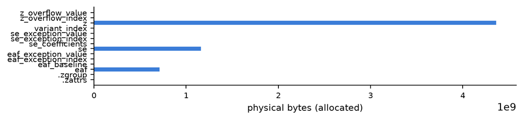

The index is derived, rebuildable data (ADR 0061): deleting it changes no association and no Analytical Metadata.

## Build cost and bounded memory

| Build | Value |
| --- | --- |
| run mode | fresh |
| configured band | 65,536,000 cells |
| physical write unit | 65,536 variants |
| declared band invariant | max(band, write unit) = 65,536,000 cells |
| largest materialised source block | 65,536,000 cells |
| largest raw buffer (cells x dtype) | 131,072,000 B |
| raw buffer by plane | `eaf` 65,536,000 B, `se` 65,536,000 B, `z` 131,072,000 B |
| prepare (open release, resolve list) | 8.20 s |
| write (planes, chunk-aligned) | 176.08 s |
| staged validation (publication gate) | 1.94 s |
| validation mode | sampled |
| decoded sample | 528 cells (corners + 16 evenly spaced Analyses + 8 physical write-unit boundaries + 1 inner-chunk boundary + 8 checksum-seeded cells per Analysis + 32 checksum-seeded cells across Analyses) |
| sample seed (input-SHA-256) | `166638625948460791` |
| publish (write + validation + staging) | 178.03 s |
| validation share of publish | 1.1% |
| in-process total | 186.23 s |
| subprocess wall total (incl. interpreter startup) | 187.53 s |
| requested / resolved / absent (writer) | 1,206,903 / 1,206,903 / 0 |
| input SHA-256 (writer) | `4a7c82aa625a006ff437dcaa2769b00e056413d54c72e98f7378327c69513398` |
| peak RSS | 1,234.8 MB |
| RSS acceptance threshold | 1,146.1 MB (the #267 4,000,000-cell declaration) |
| peak RSS within acceptance threshold | False |
| measurement source | /usr/bin/time -v (build subprocess) |
| build block source | this run |

| Statistic plane | physical files | encodings | most encodings of one file |
| --- | --- | --- | --- |
| `eaf` | 38,456 | 38,456 | 1 |
| `se` | 38,456 | 38,456 | 1 |
| `z` | 38,456 | 38,456 | 1 |

The writer copies the primary planes’ stored codes into the index **one physical output file at a time** — a v2 inner chunk or a v3 shard — so each compressed file is encoded exactly once (the table above is the measured count, not a claim). Before #270 the band was sized only by cell budget (about 1,976 variants on OGS-00009), so each 65,536-variant output chunk was partially rewritten about 33 times. The Analysis axis is tiled within the band so the largest materialised source block is `max(band_cells, write unit)` — one physical output unit when the budget is smaller — independent of the subset’s total size. A tile is a whole multiple of the primary plane’s own read unit when the budget allows, and the writer accepts decoding the primary once per tile when it does not, rather than materialising `write unit × read unit` cells.

The writer’s memory is bounded **separately from RSS**: the largest raw source block is the `largest materialised source block` cells and its `largest raw buffer` bytes above, independent of the subset’s total size.

The RSS target is the **preserved #267 acceptance threshold** listed above: the original 4,000,000-cell declaration times the same per-cell allowance plus the fixed term. It is deliberately *not* re-derived from the new band budget, so the measured peak is still compared against the historical target and the run records the miss honestly rather than being turned green by widening the model. The peak itself remains ALID-resolution-bound, not writer-band-bound.

The build’s publication gate is **`sampled`**: the enumerated structural rules (identity and attributes, exact array set, shapes/dtypes/chunking, the full Variant Index, counts, the small side-table remapping and provenance) are checked exhaustively, and the decoded Z/SE/EAF and Association Status of a bounded deterministic sample of cells are compared against the primary planes. The sample anchors a spread of physical write-unit boundaries plus a separate inner-chunk spread, the endpoints of both axes, a spread of Analyses and input-checksum-seeded cells (the mode, strategy, seed and count are in the table above); a systemic, ordering or chunk-boundary corruption is caught. An isolated unsampled corruption can pass this gate by design; standalone `opengwasdb validate` remains **exhaustive** and decodes every indexed cell, so it is the audit that rules that out.

Full decoded axis: 2,024 Analyses x 9,847,701 variants = 19,931,746,824 cells (0.1 TB at float32).

## Query latency

| Query | first read | warm median | p95 | results |
| --- | --- | --- | --- | --- |
| ordinary, before index | 44.38 s | 17.20 s | 21.33 s | 7,578,651 |
| **indexed** | 450.1 ms | 456.6 ms | 524.7 ms | 1,178,549 |
| ordinary, after index | 25.04 s | 18.83 s | 20.22 s | 7,578,651 |

| Timing method | Definition |
| --- | --- |
| first read | first full-result read of the block in the same process; the OS page cache is not dropped, so it is not a cold-cache figure, and ordinary_after runs after ordinary_before has already warmed the column |
| p95 | nearest-rank over 5 sorted warm repetitions: samples[min(N-1, int(0.95*N))] (max for N<20; N=5) |
| warm median | median of the sorted repetitions that follow the first read, on the same open store |

| Target | Outcome |
| --- | --- |
| warm median under 1 s | True |
| exact decoded equivalence | True |
| ordinary unchanged within ±25% envelope | True (median moved +9.47%) |
| ordinary before/after bracketed | True |
| peak build RSS within the #267 acceptance threshold | False |
| authoritative store unchanged | True |

## Exact equivalence (the publication gate)

Every one of the six parallel arrays must decode exactly equal, be present on both sides, be non-empty, and share dtype and length. A field missing from both sides fails: it was not measured.

| Guard | Value |
| --- | --- |
| required fields | `variant_index`, `analysis_index`, `z`, `se`, `eaf`, `association_status` |
| all six present on both sides | True |
| dtypes match | True |
| lengths match | True |
| non-empty | True |
| expected rows | 1,178,549 |
| indexed rows | 1,178,549 |

| Field | Exact |
| --- | --- |
| `analysis_index` | True |
| `association_status` | True |
| `eaf` | True |
| `se` | True |
| `variant_index` | True |
| `z` | True |

## Caveats and honesty

- **The RSS target is the preserved #267 acceptance threshold, reported as its measurement says.** The peak was 1,234.8 MB against the historical 1,146.1 MB threshold (the #267 4,000,000-cell declaration), so `peak_rss_within_bound = False`. The writer’s own bounded-band invariant (65,536,000 cells; raw buffer 131,072,000 B) is recorded separately and is not used to re-derive this acceptance target. The peak is ALID-resolution-bound, not writer-band-bound, and widening the threshold after the fact would be the tuning this harness refuses.
- **The publication gate is a documented sample; standalone validation is exhaustive.** The build’s staged validation compares a bounded deterministic decoded sample (528 cells, mode `sampled`, 1.94 s) and refuses systemic, ordering and output-boundary corruption. An isolated unsampled corruption can pass the build gate; standalone `validate` decodes and compares **every** indexed cell, side table, imputed mask and reference EAF and is the explicit audit for it. The risk is stated rather than hidden.
- **The measured rewrite count is one per physical file.** The table above is the store-level count over the staged group, so a v2 chunk (or v3 shard) encoded twice would show `most encodings of one file = 2` and fail the artifact’s semantic checks.
- **`first_ms` is not a cold-cache figure.** The OS page cache is never dropped, and `ordinary_after` follows `ordinary_before`, so it is already warm. The method is disclosed in the artifact under `timings.method`.
- **`p95_ms` is the nearest-rank order statistic, i.e. the maximum of the five warm repetitions** at the default `--reps`; it is not interpolated.
- The build block is genuine for this run (`build.run_mode = fresh`). A query-only re-run may reuse an earlier artifact’s measured build block via `--build-stats`, and it is named here as `this run`.
- **This measurement is at the commit named in Scope** (`a36ea78`, fingerprint `3e15ebba785a8538…`). It was re-run for #270’s chunk-aligned writer; both the artifact and this page are regenerated from that run.
- **`store.copy_kind` is the copy method the harness verified**, recorded as `reflink` or `full_copy` from `cp --reflink=always` with a documented fallback, or `reused_scratch_copy` when it did not perform the copy.
- The per-plane physical figures bucket the group’s top-level entries, so a future encoding that adds an array appears without a hard-coded plane list.

**NoteReproducing this measurement**

```bash
# Fresh run: copy the authoritative release into scratch with a verified
# reflink (falling back to a full copy), remove any existing subset from that
# scratch copy, measure ordinary_before, build, measure ordinary_after.
pixi run -e dev python benchmarks/benchmark_indexed_subset.py \
  --store /data/opengwasdb/stores/OGS-00009/store.opengwasdb \
  --work /data/opengwasdb/work/270-indexed \
  --analysis-id ukb-b-17805 \
  --subset-name hm3 \
  --reps 5 \
  --reuse-copy --reset-subset \
  --output docs/benchmark-output/opengwasdb_267_indexed_subset_benchmark.json
pixi run -e report quarto render \
  docs/benchmark-output/opengwasdb_267_indexed_subset_benchmark.qmd
```

Re-run the harness; never hand-edit a number in the artifact or this page.